# A quick start of PseudotimeDE

Dongyuan Song

Bioinformatics IDP, University of California, Los Angeles

dongyuansong@ucla.edu

8 May 2021

# 1 Introduction

In the investigation of molecular mechanisms underlying cell state changes, a crucial analysis is to identify differentially expressed (DE) genes along a continuous cell trajectory, which can be estimated by pseudotime inference (also callsed trajectory inference) from single-cell RNA-sequencing (scRNA-seq) data. However, the uncertainty in pseudotime inference is ignored in existing methods. *PseudotimeDE* is designed to generate **well-calibrated $p$-values**. *PseudotimeDE* is flexible in allowing users to specify the pseudotime inference method and to choose the appropriate model for scRNA-seq data.

```r
suppressPackageStartupMessages(library(PseudotimeDE))
suppressPackageStartupMessages(library(SingleCellExperiment))
suppressPackageStartupMessages(library(slingshot))
suppressPackageStartupMessages(library(tibble))
suppressPackageStartupMessages(library(dplyr))
suppressPackageStartupMessages(library(scales))
```

In this quickstart guide, we demonstrate the basic functionality of the *PseudotimeDE* package. *PseudotimeDE* package allows users to specify the pseudotime inference method, but we will use *slingshot* as the example in our analysis.

# 2 LPS dataset

```r
data(LPS_sce, package = "PseudotimeDE")
```

This Smart-seq dataset contains primary mouse dendritic cells (DCs) stimulated with lipopolysaccharide (LPS). The original data is available at Gene Expression Omnibus (GEO) under accession ID GSE45719. Here the dataset has been stored as a `SingleCellExperiment` object. For more information on how to construct it, please check *SingleCellExperiment*.

# 3 Perform pseudotime inference on the original dataset

We use *slingshot* to infer the pseudotime on the original `LPS_sce`. Since we have the prior knowledge that this dataset should be a single lineage, we let *slingshot* to generate only one lineage.

```r
norms <- as.matrix(t(assays(LPS_sce)$norms))
rd <- prcomp(norms, scale. = FALSE)$x[, 1:2]

reducedDims(LPS_sce) <- SimpleList(PCA = rd)
colData(LPS_sce)$cl <- 1

fit_ori <- slingshot(LPS_sce, reducedDim = 'PCA', clusterLabels = "cl")
LPS_ori_tbl <- tibble(cell = colnames(LPS_sce), pseudotime = rescale(colData(fit_ori)$slingPseudotime_1))
```

Check the input format.

```r
head(LPS_ori_tbl)
```

```
## # A tibble: 6 x 2
##   cell       pseudotime
##   <chr>           <dbl>
## 1 LPS_1h_S10      0.384
## 2 LPS_1h_S11      0.308
## 3 LPS_1h_S12      0.393
## 4 LPS_1h_S13      0.344
## 5 LPS_1h_S14      0.153
## 6 LPS_1h_S15      0.367
```

# 4 Perform pseudotime inference on subsamples

The key step of *PseudotimeDE* is to use **subsampling** to get the uncertainty of inferred pseudotime. The default is using 80% cells. To save time, here we only generate 2 subsamples. The defulat is using 1000 subsamples, although 100 subsamples show similar performance in our empirical study. Of course, more subsamples will lead to more accurate results.

```r
set.seed(123)
options(mc.cores = 2)
LPS_index <- mclapply(seq_len(2), function(x) {
  sample(x = c(1:dim(LPS_sce)[2]), size = 0.8*dim(LPS_sce)[2], replace = FALSE)
})
```

Users should use the exact same procedure as they used in pseudotime inference on the original dataset.

```r
LPS_sub_tbl <- mclapply(LPS_index, function(x, sce) {
  sce <- sce[, x]
  norms <- as.matrix(t(assays(sce)$norms))
  rd <- prcomp(norms, scale. = FALSE)$x[, 1:2]
  reducedDims(sce) <- SimpleList(PCA = rd)

  fit <- slingshot(sce, reducedDim = 'PCA', clusterLabels = "cl")
  tbl <- tibble(cell = colnames(sce), pseudotime = rescale(colData(fit)$slingPseudotime_1))

  ## Make sure the direction is the same as the original pseudotime
  merge.tbl <- left_join(tbl, LPS_ori_tbl, by = "cell")

  if(cor(merge.tbl$pseudotime.x, merge.tbl$pseudotime.y) < 0) {
    tbl <- dplyr::mutate(tbl, pseudotime = 1-pseudotime)
  }

  tbl
}, sce = LPS_sce)
```

We load the example `LPS_ori_tbl` and `LPS_sub_tbl` for the next DE test.

```r
data(LPS_ori_tbl, package = "PseudotimeDE")
data(LPS_sub_tbl, package = "PseudotimeDE")
```

Users can check the spreadness of the inferred pseudotime on subsamples.

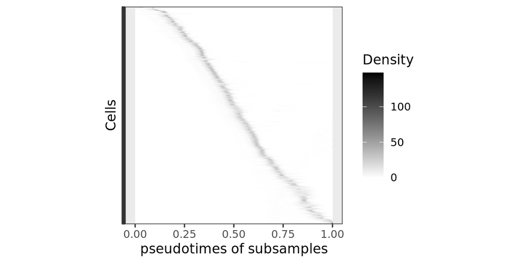

```r
PseudotimeDE::plotUncertainty(LPS_ori_tbl, LPS_sub_tbl)
```

# 5 Perform DE test

```r
system.time(res <- PseudotimeDE::runPseudotimeDE(gene.vec = c("CCL5", "CXCL10"),
                                     ori.tbl = LPS_ori_tbl,
                                     sub.tbl = LPS_sub_tbl[1:50],
                                     sce = LPS_sce,
                                     model = "nb"))
```

```
##    user  system elapsed
##  40.286   3.964  23.399
```

We can check the output.

```r
print(res)
```

```
## # A tibble: 2 x 12
##   gene    fix.pv emp.pv   para.pv ad.pv  rank gam.fit zinf    aic expv.quantile
##   <chr>    <dbl>  <dbl>     <dbl> <dbl> <dbl> <list>  <lgl> <dbl> <list>
## 1 CCL5  6.74e-29 0.0196 1.04e-153 0.924  4.13 <gam>   FALSE 7665. <dbl [5]>
## 2 CXCL… 3.53e- 9 0.0196 2.15e- 17 0.291  4.23 <gam>   FALSE 6388. <dbl [5]>
## # … with 2 more variables: expv.mean <dbl>, expv.zero <dbl>
```

`para.pv` is the most important output - the $p$-values of DE test. `rank` measures how wiggling the gene trajectory is. `gam.fit` is the fitted Generalized Additive Model (GAM).

Although we do not encourage this, users may choose completely ignore the uncertainty of inferred pseudotime, and use the $p$-values based on an asymptotic distribution (`fix.pv`). Note that `fix.pv` usually do not behaive correctly under the null (i.g., following a $\operatorname{Uniform}(0, 1)$ distribution). The good thing is that only caluclating `fix.pv` makes the DE test very fast.

```r
res_fix <- PseudotimeDE::runPseudotimeDE(gene.vec = c("CCL5", "CXCL10"),
                                     ori.tbl = LPS_ori_tbl,
                                     sub.tbl = NULL, # Set as NULL to only get fix.pv
                                     sce = LPS_sce,
                                     model = "nb")

print(res_fix)
```

```
## # A tibble: 2 x 12
##   gene    fix.pv emp.pv para.pv ad.pv  rank gam.fit zinf    aic expv.quantile
##   <chr>    <dbl> <lgl>  <lgl>   <lgl> <dbl> <list>  <lgl> <dbl> <list>
## 1 CCL5  6.74e-29 NA     NA      NA     4.13 <gam>   FALSE 7665. <dbl [5]>
## 2 CXCL… 3.53e- 9 NA     NA      NA     4.23 <gam>   FALSE 6388. <dbl [5]>
## # … with 2 more variables: expv.mean <dbl>, expv.zero <dbl>
```

We can visualize the gene trajectories estimated by `gam.fit`.

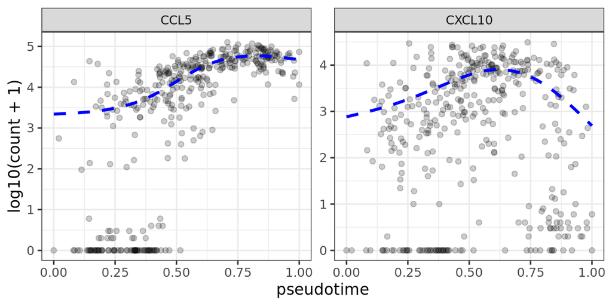

```r
PseudotimeDE::plotCurve(gene.vec = res$gene,
                                        ori.tbl = LPS_ori_tbl,
                                        sce = LPS_sce,
                                        model.fit = res$gam.fit)
```

The “dropout” problem (extra zeros) can be captured by using Zero-Inflated Negative-Binomial model (ZINB). In general, we believe `model = 'nb'` should be used in most cases since using ZINB may cause lower power (see this paper [Naught all zeros in sequence count data are the same](https://www.sciencedirect.com/science/article/pii/S2001037020303986?via%3Dihub)). However, if needed, users may choose the auto decision (`model = 'auto'`) or force to use ZINB (`model = 'zinb'`).

```r
res_zinb <- PseudotimeDE::runPseudotimeDE(gene.vec = c("CCL5", "CXCL10"),
                                     ori.tbl = LPS_ori_tbl,
                                     sub.tbl = LPS_sub_tbl[1:50],
                                     sce = LPS_sce,
                                     model = "zinb")

print(res_zinb)
```

```
## # A tibble: 2 x 12
##   gene    fix.pv emp.pv  para.pv ad.pv  rank gam.fit zinf    aic expv.quantile
##   <chr>    <dbl>  <dbl>    <dbl> <dbl> <dbl> <list>  <lgl> <dbl> <list>
## 1 CCL5  1.24e-36 0.0196 3.00e-91 0.955  4.51 <gam>   TRUE  7356. <dbl [5]>
## 2 CXCL… 1.26e-10 0.0196 5.89e-18 0.787  4.26 <gam>   TRUE  6358. <dbl [5]>
## # … with 2 more variables: expv.mean <dbl>, expv.zero <dbl>
```

We can check the fitted curve by `zinb`.

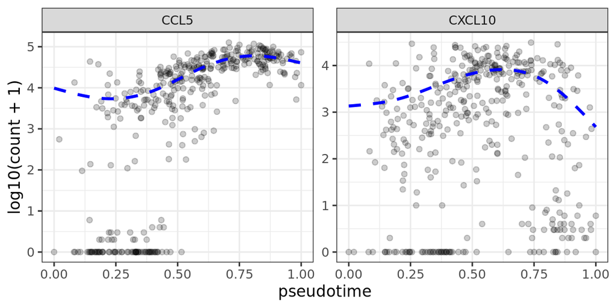

```r
PseudotimeDE::plotCurve(gene.vec = res_zinb$gene,
                                        ori.tbl = LPS_ori_tbl,
                                        sce = LPS_sce,
                                        model.fit = res_zinb$gam.fit)
```